# PanCan IRWG Immunomodulator Differential Expression in Subtypes

James A. Eddy

2017-07-20

# Summary

Testing for differences in immunomodulator mRNA expression between immune expression subtypes.

To skip past data loading / formatting, jump directly to the EDA or differential expression sections.

# Prepare data

## Retrieve data from Synapse

```r
if (!dir.exists("../data")) {
    dir.create("../data")
}
synapseLogin()
```

[output not shown]

## Collect sample IDs to exclude

Sample Quality Annotations: syn4551248 (“merged_sample_quality_annotations.tsv”)

```r
sample_qual_file <- synGet("syn4551248", downloadLocation = "../data/tcga/")
sample_qual_df <- sample_qual_file %>%
    getFileLocation() %>%
    read_tsv()
```

Remove samples based on `Do_not_use=True`, and remove cases with `AWG_excluded_because_of_pathology=True`.

```r
# samples to exclude from all datasets
exclude_samples <- sample_qual_df %>%
    mutate(AWG_excluded_because_of_pathology = parse_logical(AWG_excluded_because_of_pathology),
           Do_not_use = parse_logical(str_to_upper(Do_not_use))) %>%
    filter(AWG_excluded_because_of_pathology | Do_not_use)
```

## Gene expression sample data

### Retrieve/load data

Batch effects normalized mRNA data: syn4976363 syn4976369 (“EB++AdjustPANCAN_IlluminaHiSeq_RNASeqV2.geneExp.tsv”) syn4976366 (" EB++GeneExpAnnotation.tsv“)

Sample characteristics are stored in a tab-delimited text file (Synapse ID: `syn4976366`) and can be loaded with `read_tsv()`.

```r
# load sample data
mrna_sample_file <- mrna_files %>%
    filter(file.id == "syn4976366") %>%
    .[["file_path"]]
mrna_sample_df <- read_tsv(mrna_sample_file)
```

### Sample filtering

Remove samples from mRNA dataset.

```r
mrna_sample_df <- mrna_sample_df %>%
    filter(!(SampleID %in% exclude_samples$aliquot_barcode))
```

## Immune subtype data - MClust

### Retrieve/load data

Sample Subtypes - Workspace_Immune_Subtypes: syn8343491 syn8464746 (“five_signature_mclust_ensemble_results.tsv”)

```r
subtype_mclust_file <- "../data/tcga/five_signature_mclust_ensemble_results.tsv"
subtype_mclust_df <- read_tsv(subtype_mclust_file)
```

Note: recommend using `ClusterModel1` column

### Sample filtering

```r
subtype_mclust_df <- subtype_mclust_df %>%
    mutate(id = str_replace_all(AliquotBarcode, "\\.", "\\-")) %>%
    filter(!(id %in% exclude_samples$aliquot_barcode))
```

## Leukocyte fraction

### Retrieve/load data

Cellular Content: syn7994728 syn5808205 (“TCGA_all_leuk_estimate.masked.20170107.tsv”)

```r
# file_data <- synGet("syn5808205", downloadLocation = "./")
leuk_frac_file <- "../data/tcga/TCGA_all_leuk_estimate.masked.20170107.tsv"
leuk_frac_df <- read_tsv(leuk_frac_file, col_names = FALSE) %>%
    set_names(c("disease", "id", "leuk_frac"))
```

### Sample filtering

```r
leuk_frac_df <- leuk_frac_df %>%
    filter(!(id %in% exclude_samples$aliquot_barcode))
```

## Sample matching

Identify matched samples between mRNA and mClust data.

```r
mrna_ids <- mrna_sample_df %>%
    select(id = SampleID) %>%
    mutate(vial_id = str_replace(id, "(\\-[:alnum:]+){3}$", "")) %>%
    arrange()
subtype_mclust_ids <- subtype_mclust_df %>%
    select(id) %>%
    mutate(vial_id = str_replace(id, "(\\-[:alnum:]+){3}$", "")) %>%
    arrange()
# only keep samples with matched vial ID AND portion number
portion_id_minus_analyte_regex <- "([:alnum:]+\\-){4}[0-9]+"
mrna_subtype_mclust_shared_ids <- inner_join(
    mrna_ids, subtype_mclust_ids,
    by = "vial_id",
    suffix = c("_mrna", "_subtype_mclust")
    ) %>%
    distinct() %>%
    filter((str_extract(id_mrna, portion_id_minus_analyte_regex)
            == str_extract(id_subtype_mclust, portion_id_minus_analyte_regex)))
```

Identify matched samples between mRNA and leukocyte fraction.

```r
leuk_frac_ids <- leuk_frac_df %>%
    select(id) %>%
    mutate(vial_id = str_replace(id, "(\\-[:alnum:]+){3}$", "")) %>%
    arrange()
# only keep samples with matched vial ID AND portion number
mrna_leuk_frac_shared_ids <- inner_join(
    mrna_ids, leuk_frac_ids,
    by = "vial_id",
    suffix = c("_mrna", "_leuk_frac")
    ) %>%
    distinct() %>%
    filter((str_extract(id_mrna, portion_id_minus_analyte_regex)
            == str_extract(id_leuk_frac, portion_id_minus_analyte_regex)))
```

NOTE: 2 samples (vial IDs) were assayed on multiple plates (2x portion/plate IDs each); might need to average values across these.

## Format data for analysis

### Subset/format expression data

List of genes accessed [here](https://docs.google.com/spreadsheets/d/1aqOXYsU1ubkbxIZI_5p8ZRootgOAT0KweMA3LvSZ7HY/edit#gid=0) and saved as a TSV at `data/Cancer Immunomodulators - TCGA PanImmune Group - Direct Relationship.tsv`:

```r
gene_correlate_file <- "../data/Cancer Immunomodulators - TCGA PanImmune Group - Direct Relationship.tsv"
gene_correlate_df <- read_tsv(gene_correlate_file)
```

```
3 parsing failures.
row col  expected    actual
 20  -- 7 columns 6 columns
 61  -- 7 columns 6 columns
 64  -- 7 columns 6 columns
```

mRNA normalized, batch corrected expression values for all samples are stored as a matrix in a TSV file (Synapse ID: `syn4976369`) and can be loaded with `read_tsv()`.

```r
mrna_immunomod_file <- "../data/intermediate/mrna_immunomodulators.feather"
force_format <- FALSE # loading full expression data is slow; avoid if possible
if (!file.exists(mrna_immunomod_file) | force_format) {
    # load normalized, batch-corrected expression data
    mrna_norm_file <- mrna_files %>%
        filter(file.id == "syn4976369") %>%
        .[["file_path"]]
    mrna_norm_df <- read_tsv(mrna_norm_file, progress = FALSE)

    mrna_immunomod_df <- mrna_norm_df %>%
        separate(gene_id, c("gene_name", "gene_id"), sep = "\\|") %>%
        filter(gene_name %in% gene_correlate_df$matched_name) %>%
        select(one_of(c("gene_name", "gene_id",
                        mrna_subtype_mclust_shared_ids$id_mrna))) %>%
        gather(sample, x, -gene_name, -gene_id) %>%
        left_join(mrna_ids, by = c("sample" = "id")) %>%
        group_by(vial_id, gene_name) %>%
        summarise(x = mean(x)) %>%
        ungroup() %>%
        spread(vial_id, x)

    write_feather(mrna_immunomod_df, mrna_immunomod_file)
} else {
    mrna_immunomod_df <- read_feather(mrna_immunomod_file)
}
```

### Subset/format sample data

```r
immunomod_subtype_sample_df <- mrna_subtype_mclust_shared_ids %>%
    left_join(mrna_sample_df, by = c("id_mrna" = "SampleID")) %>%
    left_join(subtype_mclust_df, by = c("id_subtype_mclust" = "id")) %>%
    left_join(mrna_leuk_frac_shared_ids %>%
                  select(-vial_id), by = "id_mrna") %>%
    filter(!is.na(id_leuk_frac)) %>%
    left_join(leuk_frac_df, by = c("id_leuk_frac" = "id")) %>%
    select(vial_id, Center, platform, Adjustment, disease,
    ClusterModel1, leuk_frac) %>%
    group_by(vial_id, Center, platform, Adjustment, disease, ClusterModel1) %>%
    summarise(leuk_frac = mean(leuk_frac, na.rm = TRUE)) %>%
    ungroup() %>%
    arrange(ClusterModel1) %>%
    mutate(ClusterModel1 = fct_inorder(as.character(ClusterModel1)))
```

# Explore data

## Set up plotting colors

```r
tcga_colors <- tribble(
    ~Color, ~Disease,
    "#ED2891", "BRCA",
    "#B2509E", "GBM",
    "#D49DC7", "LGG",
    "#C1A72F", "ACC",
    "#E8C51D", "PCPG",
    "#F9ED32", "THCA",
    "#104A7F", "CHOL",
    "#9EDDF9", "COAD",
    "#007EB5", "ESCA",
    "#CACCDB", "LIHC",
    "#6E7BA2", "PAAD",
    "#DAF1FC", "READ",
    "#00AEEF", "STAD",
    "#F6B667", "CESC",
    "#D97D25", "OV",
    "#FBE3C7", "UCEC",
    "#F89420", "UCS",
    "#97D1A9", "HNSC",
    "#009444", "UVM",
    "#754C29", "LAML",
    "#CEAC8F", "THYM",
    "#3953A4", "DLBC",
    "#BBD642", "SKCM",
    "#00A99D", "SARC",
    "#D3C3E0", "LUAD",
    "#A084BD", "LUSC",
    "#542C88", "MESO",
    "#FAD2D9", "BLCA",
    "#ED1C24", "KICH",
    "#F8AFB3", "KIRC",
    "#EA7075", "KIRP",
    "#7E1918", "PRAD",
    "#BE1E2D", "TGCT"
)
immunomod_subtype_sample_df <- immunomod_subtype_sample_df %>%
    mutate(disease = factor(disease, levels = tcga_colors$Disease))
```

## Clean up missing data

Remove any genes with missing values in one or more samples.

```r
mrna_immunomod_df <- mrna_immunomod_df %>%
    gather(sample, x, -gene_name) %>%
    left_join(immunomod_subtype_sample_df, by = c("sample" = "vial_id")) %>%
    filter(!is.na(leuk_frac)) %>%
    group_by(gene_name) %>%
    filter(!any(is.na(x))) %>%
    ungroup()
```

```r
mrna_immunomod_df %>%
    distinct(gene_name)
```

| gene_name |
| --- |
| ADORA2A |
| BTLA |
| BTN3A1 |
| BTN3A2 |
| C10orf54 |
| CCL5 |
| CD27 |
| CD274 |
| CD276 |
| CD28 |

[output cut: 57 more lines]

## Check expression distributions

Check whether genes are (roughly) normally distributed across samples. Note: expression values in the plots below are log-transformed.

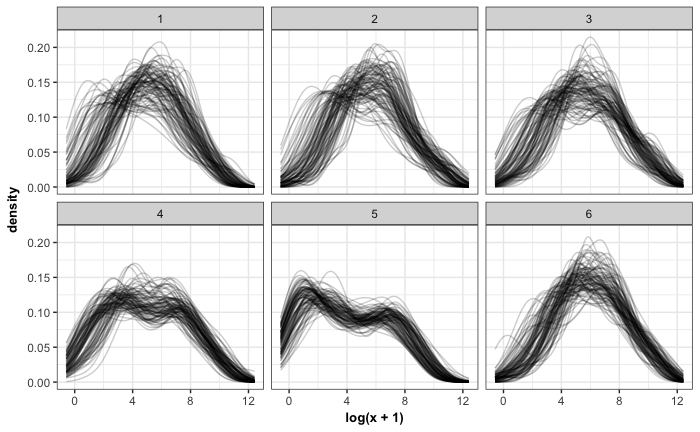

```r
mrna_immunomod_df %>%
    group_by(ClusterModel1, gene_name) %>%
    # just check first 100 samples
    slice(1:100) %>%
    ggplot(aes(x = log(x + 1))) +
    stat_density(aes(group = sample), geom = "line", position = "identity",
                 alpha = 0.2) +
    facet_wrap(~ ClusterModel1) %>%
    I
```

Seems reasonable…

## PCA

### Immunomodulator expression

PCA is computed on the log-transformed expression values.

```r
# convert expression df to matrix
mrna_immunomod_mat <- mrna_immunomod_df %>%
    mutate(log_x = log(x + 1)) %>%
    select(gene_name, sample, log_x) %>%
    spread(sample, log_x) %>%
    remove_rownames() %>%
    column_to_rownames("gene_name") %>%
    as.matrix()
mrna_immunomod_pca <- mrna_immunomod_mat %>%
    t() %>%
    prcomp()
```

#### Plotting top PCs

```r
pc_df <- mrna_immunomod_pca %>%
    tidy("pcs")
mrna_immunomod_pca_df <- mrna_immunomod_pca %>%
    tidy("samples") %>%
    filter(PC <= 2) %>%
    left_join(immunomod_subtype_sample_df, by = c("row" = "vial_id"))
```

The plot below shows samples plotted as points along the first two principle components (PCs). Points are colored by mClust cluster.

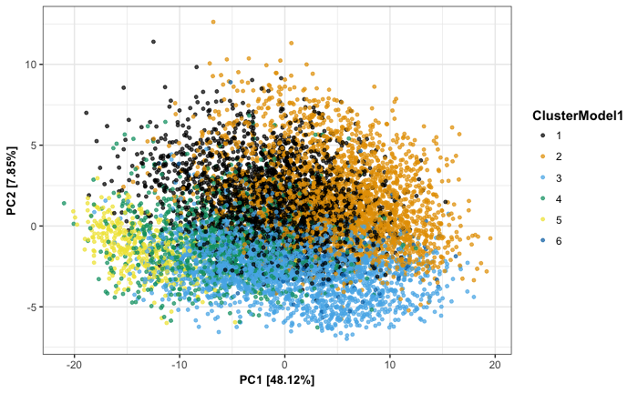

```r
pc1_label <- pc_df %>%
    filter(PC == 1) %>%
    transmute(label = sprintf("PC%s [%0.2f%%]", PC, 100*percent)) %>%
    flatten_chr()
pc2_label <- pc_df %>%
    filter(PC == 2) %>%
    transmute(label = sprintf("PC%s [%0.2f%%]", PC, 100*percent)) %>%
    flatten_chr()
mrna_immunomod_pca_df %>%
    spread(PC, value) %>%
    ggplot(aes(x = `1`, y = `2`)) +
    geom_point(aes(colour = ClusterModel1),
               size = 1, alpha = 0.7) +
    xlab(pc1_label) +
    ylab(pc2_label)
```

Breaking clusters out into separate facets, to highlight position of points for each…

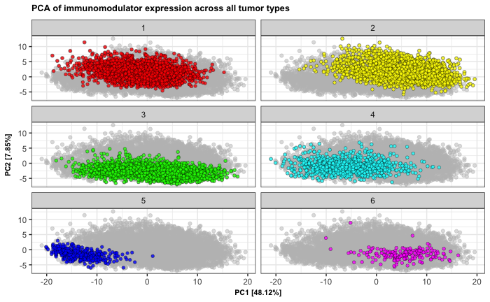

```r
subtype_colors <- c("red", "yellow", "green", "cyan", "blue", "magenta")
bg_df <- mrna_immunomod_pca_df %>%
    spread(PC, value) %>%
    select(-ClusterModel1)
p <- mrna_immunomod_pca_df %>%
    spread(PC, value) %>%
    ggplot(aes(x = `1`, y = `2`)) +
    geom_point(data = bg_df, colour = "gray", size = 1.5, alpha = 0.5) +
    geom_point(aes(fill = ClusterModel1), size = 1.5, alpha = 0.8,
               shape = 21, colour = "black", stroke = 0.2) +
    scale_fill_manual(values = subtype_colors) +
    guides(fill = FALSE) +
    xlab(pc1_label) +
    ylab(pc2_label) +
    facet_wrap(~ ClusterModel1, ncol = 2) +
    ggtitle("PCA of immunomodulator expression across all tumor types") +
    theme(title = element_text(size = 8),
          axis.title.x = element_text(size = 8),
          axis.title.y = element_text(size = 8))
p
ggsave("../figures/Immunomod-SubtypePCA_20170720.pdf", p,
       width = 6, height = 10, units = "cm", dpi = 300, scale = 2)
```

This plot shows points colored by cancer type.

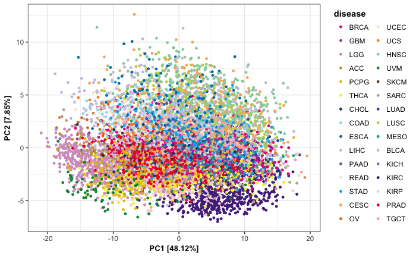

```r
mrna_immunomod_pca_df %>%
    spread(PC, value) %>%
    ggplot(aes(x = `1`, y = `2`)) +
    geom_point(aes(colour = disease), size = 1) +
    xlab(pc1_label) +
    ylab(pc2_label) +
    scale_colour_manual(values = tcga_colors$Color)
```

Points colored by leukocyte fraction.

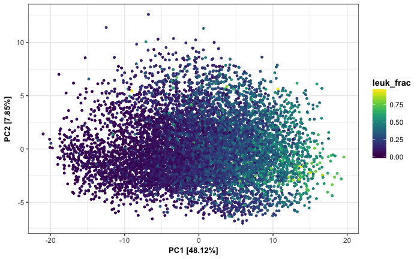

```r
mrna_immunomod_pca_df %>%
    spread(PC, value) %>%
    ggplot(aes(x = `1`, y = `2`)) +
    geom_point(aes(colour = leuk_frac), size = 1) +
    xlab(pc1_label) +
    ylab(pc2_label)
```

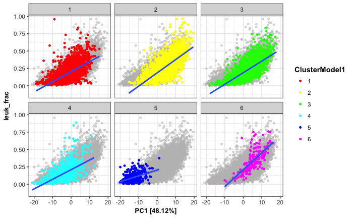

```r
bg_df <- mrna_immunomod_pca_df %>%
    spread(PC, value) %>%
    select(-ClusterModel1)
mrna_immunomod_pca_df %>%
    spread(PC, value) %>%
    ggplot(aes(x = `1`, y = leuk_frac)) +
    geom_point(data = bg_df, colour = "gray", size = 1, alpha = 0.5) +
    geom_point(aes(colour = ClusterModel1), size = 1) +
    geom_smooth(method = "lm") +
    xlab(pc1_label) +
    # ylab(pc2_label) +
    scale_colour_manual(values = subtype_colors) +
    facet_wrap(~ ClusterModel1)
```

```r
mrna_immunomod_pca %>%
    tidy("samples") %>%
    filter(PC == 1) %>%
    select(PC = value, vial_id = row) %>%
    left_join(immunomod_subtype_sample_df, by = "vial_id") %>%
    do(tidy(lm(PC ~ leuk_frac, data = .))) %>%
    I
```

```
joining character vector and factor, coercing into character vector
```

|  | term | estimate | std.error | statistic | p.value |
| --- | --- | --- | --- | --- | --- |
| 1 | (Intercept) | -7.339115 | 0.08896914 | -82.49057 | 0 |
| 2 | leuk_frac | 35.641548 | 0.35205446 | 101.23873 | 0 |

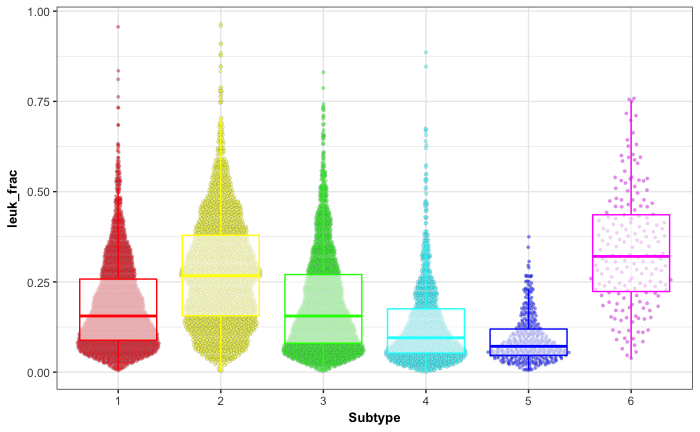

```r
mrna_immunomod_pca_df %>%
    spread(PC, value) %>%
    ggplot(aes(x = ClusterModel1, y = leuk_frac)) +
    geom_quasirandom(aes(fill = ClusterModel1), size = 1, alpha = 0.5,
                     shape = 21, colour = "slategray", stroke = 0.2) +
    geom_boxplot(aes(colour = ClusterModel1), alpha = 0.6,
                 outlier.size = 0, outlier.alpha = 0) +    xlab(pc1_label) +
    scale_color_manual(values = subtype_colors) +
    scale_fill_manual(values = subtype_colors) +
    guides(fill = FALSE, colour = FALSE) +
    xlab("Subtype")
```

#### Batch effects?

I used a simple ANOVA to check the association with each factor variable in the sample data and PC1. Pretty much everything but `platform` came up as highly significant (but this is with ~9,000 samples, so maybe not too surprising).

```r
mrna_immunomod_pca %>%
    tidy("samples") %>%
    filter(PC == 1) %>%
    select(PC = value, vial_id = row) %>%
    left_join(immunomod_subtype_sample_df, by = "vial_id") %>%
    select(-vial_id, -leuk_frac) %>%
    gather(variable, value, -PC) %>%
    group_by(variable) %>%
    do(tidy(anova(lm(PC ~ value, .)))) %>%
    filter(term != "Residuals") %>%
    # ggplot(aes(x = variable, y = -log10(p.value))) +
    # geom_point() +
    # geom_hline(yintercept = -log10(0.05), linetype = 2) %>%
    I
```

|  | variable | term | df | sumsq | meansq | statistic | p.value |
| --- | --- | --- | --- | --- | --- | --- | --- |
| 1 | Adjustment | value | 3 | 2195.2986 | 731.7662 | 14.356638 | 2.497995e-09 |
| 2 | Center | value | 1 | 1553.4019 | 1553.4019 | 30.440585 | 3.538010e-08 |
| 3 | ClusterModel1 | value | 5 | 174672.5991 | 34934.5198 | 1098.692049 | 0.000000e+00 |
| 4 | disease | value | 29 | 178243.8470 | 6146.3396 | 195.225615 | 0.000000e+00 |
| 5 | platform | value | 1 | 33.2512 | 33.2512 | 0.649442 | 4.203335e-01 |

Taking a look at the overlap between some of the relevant variables. The effect of `Center` and `Adjustment` are likely to be closely related.

```r
table(immunomod_subtype_sample_df$Adjustment, immunomod_subtype_sample_df$Center)
```

```
               BCGSC  UNC
  EBNplus          0  584
  EBNplus&Mean    38    0
  Mean           792    0
  No Change        0 7582
```

Fortunately, clusters don’t seem to be obviously described by `Adjustment` or `Center` (from what I’ve seen of the manuscript, not cancer type either).

```r
table(immunomod_subtype_sample_df$Adjustment, immunomod_subtype_sample_df$ClusterModel1)
```

```
                  1    2    3    4    5    6
  EBNplus       347  165   54   18    0    0
  EBNplus&Mean    7   23    2    4    0    2
  Mean          238  432   44   71    0    7
  No Change    1804 1953 2241 1033  381  170
```

```r
table(immunomod_subtype_sample_df$Center, immunomod_subtype_sample_df$ClusterModel1)
```

```
           1    2    3    4    5    6
  BCGSC  245  455   46   75    0    9
  UNC   2151 2118 2295 1051  381  170
```

PC plots for `Adjustment`:

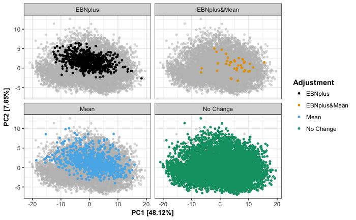

```r
bg_df <- mrna_immunomod_pca_df %>%
    spread(PC, value) %>%
    select(-Adjustment)
mrna_immunomod_pca_df %>%
    spread(PC, value) %>%
    ggplot(aes(x = `1`, y = `2`, colour = Adjustment)) +
    geom_point(data = bg_df, colour = "gray", size = 1, alpha = 0.5) +
    geom_point(size = 1) +
    xlab(pc1_label) +
    ylab(pc2_label) +
    facet_wrap(~ Adjustment)
```

### Checking with all highly expressed genes

Trying to see whether some of these trends are also present when I include more genes for PCA.

```r
# mrna_norm_df <- data.table::fread("../data/tcga/EB++AdjustPANCAN_IlluminaHiSeq_RNASeqV2.geneExp.tsv")
```

I’ll randomly select 1000 samples, just to make the computation a bit less cumbersome, and I’ll keep the top 1000 highly expressed genes (on average across samples).

```r
# rand_samples <- sample(1:ncol(mrna_norm_df) - 1, 1000)
# mrna_norm_mat <- mrna_norm_df %>%
#     as_data_frame() %>%
#     select(-gene_id) %>%
#     as.matrix()
# rownames(mrna_norm_mat) <- mrna_norm_df$gene_id
# mrna_norm_mat <- mrna_norm_mat[complete.cases(mrna_norm_mat), ]
#
# top_mrna <- mrna_norm_mat %>%
#     rowMeans(na.rm = TRUE) %>%
#     sort(decreasing = TRUE) %>%
#     head(1000) %>%
#     names()
#
# top_mrna_mat <- mrna_norm_mat[top_mrna, rand_samples]
# rm(mrna_norm_mat)
```

```r
# # convert expression df to matrix
# top_mrna_pca <- top_mrna_mat %>%
#     magrittr::add(1) %>%
#     log() %>%
#     t() %>%
#     prcomp()
```

```r
# pc2_df <- top_mrna_pca %>%
#     tidy("pcs")
#
# top_mrna_pca_df <- top_mrna_pca %>%
#     tidy("samples") %>%
#     filter(PC <= 2) %>%
#     left_join(mrna_subtype_mclust_shared_ids, by = c("row" = "id_mrna")) %>%
#     filter(!is.na(vial_id)) %>%
#     left_join(mrna_sample_df, by = c("row" = "SampleID")) %>%
#     left_join(subtype_mclust_df, by = c("id_subtype_mclust" = "id")) %>%
#     left_join(sample_qual_df, by = c("row" = "aliquot_barcode")) %>%
#     arrange(ClusterModel1) %>%
#     mutate(ClusterModel1 = fct_inorder(as.character(ClusterModel1)))
```

```r
# pc1_label <- pc2_df %>%
#     filter(PC == 1) %>%
#     transmute(label = sprintf("PC%s [%0.2f%%]", PC, 100*percent)) %>%
#     flatten_chr()
#
# pc2_label <- pc2_df %>%
#     filter(PC == 2) %>%
#     transmute(label = sprintf("PC%s [%0.2f%%]", PC, 100*percent)) %>%
#     flatten_chr()
#
# top_mrna_pca_df %>%
#     spread(PC, value) %>%
#     ggplot(aes(x = `1`, y = `2`)) +
#     geom_point(aes(colour = ClusterModel1), size = 1.5) +
#     xlab(pc1_label) +
#     ylab(pc2_label)
```

```r
# top_mrna_pca %>%
#     tidy("samples") %>%
#     filter(PC == 1) %>%
#     select(PC = value, row) %>%
#     left_join(mrna_subtype_mclust_shared_ids, by = c("row" = "id_mrna")) %>%
#     filter(!is.na(vial_id)) %>%
#     left_join(mrna_sample_df, by = c("row" = "SampleID")) %>%
#     left_join(subtype_mclust_df, by = c("id_subtype_mclust" = "id")) %>%
#     left_join(sample_qual_df, by = c("row" = "aliquot_barcode")) %>%
#     select(PC, Center, platform = `platform.x`, Adjustment, ClusterModel1,
#            disease = `cancer type`) %>%
#     arrange(ClusterModel1) %>%
#     mutate(ClusterModel1 = fct_inorder(as.character(ClusterModel1))) %>%
#     gather(variable, value, -PC) %>%
#     group_by(variable) %>%
#     do(tidy(anova(lm(PC ~ value, .)))) %>%
#     ggplot(aes(x = variable, y = -log10(p.value))) +
#     geom_point() +
#     geom_hline(yintercept = -log10(0.05), linetype = 2)
```

# Differential expression testing

Given some of the trends above, I’m not sure how much I’d trust these results, but I went ahead and tested whether any the immunomodulator genes showed significant differences in expression across clusters. I first tried ANOVA and then switched to Kruskal-Wallis; in both cases, I get pretty much perfect p-values across the board.

```r
dge_df <- mrna_immunomod_df %>%
    mutate(log_x = log(x + 1)) %>%
    group_by(gene_name) %>%
    do(tidy(anova(lm(log_x ~ 0 + ClusterModel1, .)))) %>%
    # do(tidy(kruskal.test(log_x ~ 0 + ClusterModel1, .))) %>%
    ungroup() %>%
    # filter(term == "ClusterModel1") %>%
    filter(term != "Residuals") %>%
    arrange(desc(statistic)) %>%
    I
dge_df[["p.adjust"]] <- p.adjust(dge_df$p.value, method = "BH")
dge_df %>%
    select(gene_name, term, statistic, p.value, p.adjust)
```

|  | gene_name | term | statistic | p.value | p.adjust |
| --- | --- | --- | --- | --- | --- |
| 1 | HMGB1 | ClusterModel1 | 726249.265 | 0 | 0 |
| 2 | CD276 | ClusterModel1 | 319756.748 | 0 | 0 |
| 3 | HLA-C | ClusterModel1 | 316314.004 | 0 | 0 |
| 4 | HLA-A | ClusterModel1 | 267016.704 | 0 | 0 |
| 5 | HLA-B | ClusterModel1 | 257230.193 | 0 | 0 |
| 6 | VEGFB | ClusterModel1 | 205531.152 | 0 | 0 |
| 7 | ENTPD1 | ClusterModel1 | 199163.445 | 0 | 0 |
| 8 | BTN3A1 | ClusterModel1 | 176051.265 | 0 | 0 |
| 9 | BTN3A2 | ClusterModel1 | 150787.508 | 0 | 0 |
| 10 | MICA | ClusterModel1 | 121826.307 | 0 | 0 |

[output cut: 57 more lines]

```r
dge_df <- mrna_immunomod_df %>%
    mutate(log_x = log(x + 1)) %>%
    group_by(gene_name) %>%
    # do(tidy(anova(lm(log_x ~ 0 + ClusterModel1 + leuk_frac + ClusterModel1*leuk_frac, .)))) %>%
    do(tidy(kruskal.test(log_x ~ 0 + ClusterModel1, .))) %>%
    ungroup() %>%
    # filter(term == "ClusterModel1") %>%
    # filter(term != "Residuals") %>%
    arrange(desc(statistic)) %>%
    I
```

```
|=============================================================================================|100% ~0 s remaining
```

```r
dge_df[["p.adjust"]] <- p.adjust(dge_df$p.value, method = "BH")
dge_df %>%
    select(gene_name, statistic, p.value, p.adjust)
```

|  | gene_name | statistic | p.value | p.adjust |
| --- | --- | --- | --- | --- |
| 1 | EDNRB | 3433.5935 | 0.000000e+00 | 0.000000e+00 |
| 2 | CXCL10 | 3405.8837 | 0.000000e+00 | 0.000000e+00 |
| 3 | ICOS | 3345.6800 | 0.000000e+00 | 0.000000e+00 |
| 4 | CCL5 | 3143.3403 | 0.000000e+00 | 0.000000e+00 |
| 5 | CTLA4 | 2972.7007 | 0.000000e+00 | 0.000000e+00 |
| 6 | IDO1 | 2963.0347 | 0.000000e+00 | 0.000000e+00 |
| 7 | TNFRSF18 | 2952.9414 | 0.000000e+00 | 0.000000e+00 |
| 8 | SLAMF7 | 2873.4277 | 0.000000e+00 | 0.000000e+00 |
| 9 | TIGIT | 2819.8334 | 0.000000e+00 | 0.000000e+00 |
| 10 | LAG3 | 2779.2689 | 0.000000e+00 | 0.000000e+00 |

[output cut: 57 more lines]

```r
# dge_df
```

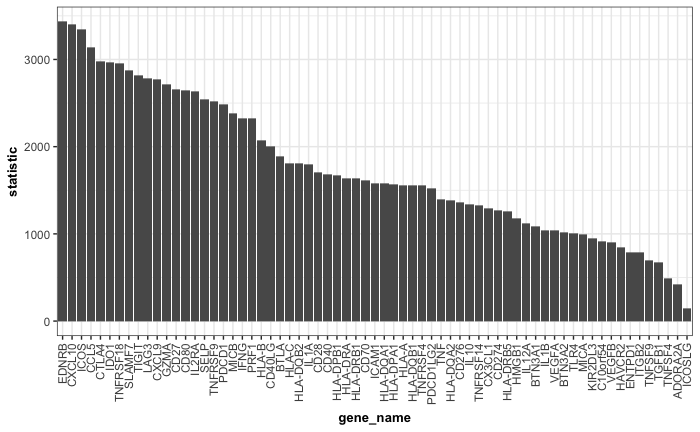

```r
dge_df %>%
    arrange(desc(statistic)) %>%
    mutate(gene_name = fct_inorder(gene_name)) %>%
    ggplot(aes(x = gene_name, y = statistic)) +
    geom_col() +
    theme(axis.text.x = element_text(angle = 90, vjust = 0.5, hjust = 1))
```

Picking a few of the top genes (based on test statistic… as p-value isn’t very useful), I can see how their distributions are changing across clusters. There certainly seems to be a reasonable difference, but I don’t know how interesting this is.

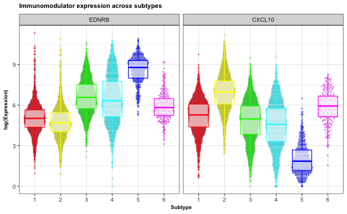

```r
subtype_colors <- c("red", "yellow", "green", "cyan", "blue", "magenta")
top_genes <- dge_df %>%
    slice(1:2) %>%
    .[["gene_name"]]
p <- mrna_immunomod_df %>%
    filter(gene_name %in% top_genes) %>%
    mutate(gene_name = factor(gene_name, levels = top_genes)) %>%
    mutate(log_x = log(x + 1)) %>%
    ggplot(aes(y = log_x, x = ClusterModel1)) +
    geom_quasirandom(aes(fill = ClusterModel1), size = 1, alpha = 0.5,
                     shape = 21, colour = "slategray", stroke = 0.2) +
    geom_boxplot(aes(colour = ClusterModel1), alpha = 0.6,
                 outlier.size = 0, outlier.alpha = 0) +
    scale_fill_manual(values = subtype_colors) +
    scale_colour_manual(values = subtype_colors) +
    guides(colour = FALSE, fill = FALSE) +
    ylab("log(Expression)") +
    xlab("Subtype") +
    facet_wrap(~ gene_name, ncol = 3) +
    ggtitle("Immunomodulator expression across subtypes") +
    theme(title = element_text(size = 8),
          axis.title.x = element_text(size = 8),
          axis.title.y = element_text(size = 8))
p
ggsave("../figures/Immunomod-SubtypeDGE_expressionDists_20170720.pdf", p,
       width = 10, height = 4.5, units = "cm", dpi = 300, scale = 2)
```

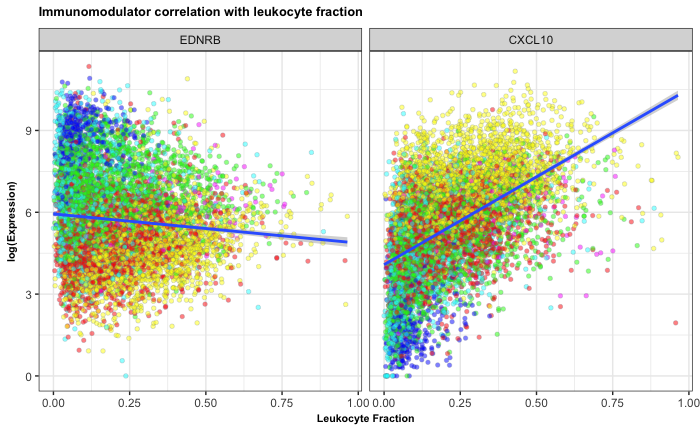

```r
p <- mrna_immunomod_df %>%
    filter(gene_name %in% top_genes) %>%
    mutate(gene_name = factor(gene_name, levels = top_genes)) %>%
    mutate(log_x = log(x + 1)) %>%
    ggplot(aes(y = log_x, x = leuk_frac)) +
    geom_point(aes(fill = ClusterModel1), size = 1.5, alpha = 0.5,
               shape = 21, colour = "slategray", stroke = 0.2) +
    geom_smooth(method = "lm") +
    scale_fill_manual(values = subtype_colors) +
    guides(fill = FALSE) +
    ylab("log(Expression)") +
    xlab("Leukocyte Fraction") +
    facet_wrap(~ gene_name) +
    ggtitle("Immunomodulator correlation with leukocyte fraction") +
    theme(title = element_text(size = 8),
          axis.title.x = element_text(size = 8),
          axis.title.y = element_text(size = 8))
p
ggsave("../figures/Immunomod-SubtypeDGE_CorrLF_20170720.pdf", p,
       width = 10, height = 4.5, units = "cm", dpi = 300, scale = 2)
```

Perhaps it would be better to restrict testing to within each cancer type? Or maybe I need to be going about this in a different way altogether…